# Million-aire: How census tracts affect air quality monitoring in Ventura County

Kayla Geronimo-Anctil

This page uses the following packages:

- `sf`
- `tidyverse`
- `RAQSAPI`
- `flextable`
- `shadowtext`
- `ggdark`

## Research Hypotheses:

- Team Research Hypotheses: Marginalized communities are subjected to higher than average levels of PM2.5 and ozone.
- Kayla’s Research Hypothesis: The biggest gaps in county air data are in DACs.
- Ashley’s Research Hypothesis: Childhood asthma correlates with VC air quality. PM2.5 shows the clearest trend.

## PurpleAir

To get purpleair.csv, the terminal/Bash was used to retrieve monitor data from PurpleAir. The only monitor data that I could retrieve was public, so if any monitors were private I couldn’t use them in the analysis.  
The EPSG code for NAD83 / California Zone 5 (in meters) is 26945. To transform an sf object into this CRS, you will see this piece of code again later: `... %>% st_transform(26945)`.

```r
pa_monitors <- read_csv("purpleair.csv")

#By convention, the coordinate reference system used for longitude / latitude data is WGS 1984, represented with the EPSG code 4326
#Had to go in terms of convention because the dataset does not say what crs is used, and I couldn't find this online
pa_monitors_sf <- pa_monitors %>%
  st_as_sf(coords = c("longitude","latitude"), #turn pa_monitors into an sf object
               crs = 4326) %>%
  st_transform(26945) #26945 is the epsg code for nad83 / california zone 5 in meters
```

## CalEnviroScreen4.0 (CES4)

These were downloaded off of the CES website.

```r
CES4_main <- read_csv("data_raw/CES4_spreadsheet.xlsx - CES4.0FINAL_results.csv")
CES4_demo <- read_csv("data_raw/CES4_spreadsheet.xlsx - Copy of Demographic Profile.csv")

CES4_join <- full_join(CES4_main, CES4_demo, by = c("Census Tract", "CES 4.0 Score", "CES 4.0 Percentile", "CES 4.0 Percentile Range",
                                              "Total Population", "California County"))

CES4 <- CES4_join %>%
  filter(`California County` == "Ventura")
```

## EPA AQS

Websites of interest:

- https://aqs.epa.gov/aqsweb/documents/data_api.html#tips
- https://cran.r-project.org/web/packages/RAQSAPI/RAQSAPI.pdf

Before running anything that uses the `RAQSAPI` (R AQS API) package, you need to run your credentials. As I do not want to share my API key publicly, here is the method that I used:

```r
#think of aqs credentials like how often you call in the library (once every time that you start a new R session)
aqs_credentials(username = "YOUR_USERNAME",
                         key = "YOUR_API_KEY")
```

California FIPS = 06  
County code:

- Ventura = 111
- Santa Barbara = 083
- Los Angeles = 037

Parameters by class:

- Ozone = 44201,
- PM2.5 - Local Conditions = 88101

### Ventura County

This chunk below is just finding the monitors that were operating in 2020, that were collecting Ozone and PM2.5 data. This is for Ventura County.

```r
aqs_monitorsK <- aqs_monitors_by_county(
  parameter = c("44201", "88101"),
  bdate=as.Date("20200101", format="%Y%m%d"),
  edate=as.Date("20201231", format="%Y%m%d"),
  stateFIPS = "06",
  countycode = "111")
```

Here is what that looks like…

```r
aqs_monitorsK
```

| state_code | county_code | site_number | parameter_code | poc | parameter_name | open_date | close_date | concurred_exclusions | dominant_source | measurement_scale | measurement_scale_def | monitoring_objective | last_method_code | last_method_description | last_method_begin_date | naaqs_primary_monitor | qa_primary_monitor | monitor_type | networks | monitoring_agency_code | monitoring_agency | si_id | latitude | longitude | datum | lat_lon_accuracy | elevation | probe_height | pl_probe_location | … |
| --- | --- | --- | --- | --- | --- | --- | --- | --- | --- | --- | --- | --- | --- | --- | --- | --- | --- | --- | --- | --- | --- | --- | --- | --- | --- | --- | --- | --- | --- | --- |
| 06 | 111 | 1004 | 44201 | 1 | Ozone | 1996-04-01 | NA | NA | MOBILE | URBAN SCALE | 4 KM TO 50 KM | POPULATION EXPOSURE | 087 | INSTRUMENTAL - ULTRA VIOLET ABSORPTION | 2003-06-01 | Y | NA | SLAMS | NA | 1118 | Ventura County APCD | 1614 | 34.44806 | -119.2313 | NAD83 | 910.88 | 262 | 4 | TOP OF BUILDING | … |
| 06 | 111 | 3001 | 44201 | 1 | Ozone | 1979-01-01 | NA | NA | AREA | URBAN SCALE | 4 KM TO 50 KM | POPULATION EXPOSURE | 087 | INSTRUMENTAL - ULTRA VIOLET ABSORPTION | 2002-04-01 | Y | NA | SLAMS | PAMS | 1118 | Ventura County APCD | 1619 | 34.25239 | -119.1432 | NAD83 | 0.00 | 43 | 4 | TOP OF BUILDING | … |
| 06 | 111 | 0007 | 44201 | 1 | Ozone | 1992-03-01 | NA | NA | NA | URBAN SCALE | 4 KM TO 50 KM | POPULATION EXPOSURE; UNKNOWN | 087 | INSTRUMENTAL - ULTRA VIOLET ABSORPTION | 2002-08-01 | Y | NA | SLAMS | NA | 1118 | Ventura County APCD | 1608 | 34.21017 | -118.8705 | NAD83 | 0.00 | 244 | 5 | NA | … |
| 06 | 111 | 2002 | 44201 | 1 | Ozone | 1985-06-01 | NA | NA | MOBILE | URBAN SCALE | 4 KM TO 50 KM | HIGHEST CONCENTRATION | 087 | INSTRUMENTAL - ULTRA VIOLET ABSORPTION | 2002-08-01 | Y | NA | SLAMS | PAMS | 1118 | Ventura County APCD | 1617 | 34.27632 | -118.6837 | NAD83 | 0.00 | 314 | 4 | TOP OF BUILDING | … |
| 06 | 111 | 0009 | 44201 | 1 | Ozone | 2000-11-03 | NA | NA | NA | URBAN SCALE | 4 KM TO 50 KM | HIGHEST CONCENTRATION | 087 | INSTRUMENTAL - ULTRA VIOLET ABSORPTION | 2002-06-01 | Y | NA | SLAMS | NA | 1118 | Ventura County APCD | 1610 | 34.40428 | -118.8100 | NAD83 | 3.04 | 190 | 3 | TOP OF BUILDING | … |
| 06 | 111 | 2002 | 88101 | 4 | PM2.5 - Local Conditions | 2014-03-17 | NA | NA | NA | NEIGHBORHOOD | 500 M TO 4KM | HIGHEST CONCENTRATION | 170 | Met One BAM-1020 Mass Monitor w/VSCC - Beta Attenuation | 2014-03-17 | NA | NA | SLAMS | NA | 1118 | Ventura County APCD | 1617 | 34.27632 | -118.6837 | NAD83 | 0.00 | 314 | NA | TOP OF BUILDING | … |
| 06 | 111 | 0009 | 88101 | 3 | PM2.5 - Local Conditions | 2011-11-15 | NA | NA | NA | NEIGHBORHOOD | 500 M TO 4KM | HIGHEST CONCENTRATION | 170 | Met One BAM-1020 Mass Monitor w/VSCC - Beta Attenuation | 2011-11-15 | Y | NA | SLAMS | NA | 1118 | Ventura County APCD | 1610 | 34.40428 | -118.8100 | NAD83 | 3.04 | 190 | NA | TOP OF BUILDING | … |
| 06 | 111 | 2002 | 88101 | 3 | PM2.5 - Local Conditions | 2013-06-29 | NA | NA | NA | NEIGHBORHOOD | 500 M TO 4KM | HIGHEST CONCENTRATION | 170 | Met One BAM-1020 Mass Monitor w/VSCC - Beta Attenuation | 2013-06-29 | Y | Y | SLAMS | NA | 1118 | Ventura County APCD | 1617 | 34.27632 | -118.6837 | NAD83 | 0.00 | 314 | NA | TOP OF BUILDING | … |
| 06 | 111 | 3001 | 88101 | 3 | PM2.5 - Local Conditions | 2012-01-26 | NA | NA | NA | NEIGHBORHOOD | 500 M TO 4KM | POPULATION EXPOSURE | 170 | Met One BAM-1020 Mass Monitor w/VSCC - Beta Attenuation | 2012-01-26 | Y | NA | SLAMS | NA | 1118 | Ventura County APCD | 1619 | 34.25239 | -119.1432 | NAD83 | 0.00 | 43 | NA | TOP OF BUILDING | … |
| 06 | 111 | 0007 | 88101 | 3 | PM2.5 - Local Conditions | 2012-01-07 | NA | NA | NA | NEIGHBORHOOD | 500 M TO 4KM | POPULATION EXPOSURE | 170 | Met One BAM-1020 Mass Monitor w/VSCC - Beta Attenuation | 2012-01-07 | Y | NA | SLAMS | NA | 1118 | Ventura County APCD | 1608 | 34.21017 | -118.8705 | NAD83 | 0.00 | 244 | NA | TOP OF BUILDING | … |

[output cut: 1 more lines]

And now I am just turning it into an sf object. See the first code chunk under “PurpleAir” for more.

```r
# datum column lists it as NAD83, EPSG code 4269
aqs_monitorsK_sf <- aqs_monitorsK %>%
  st_as_sf(coords = c("longitude","latitude"),
               crs = 4269) %>%
  st_transform(26945)
```

### Santa Barbara County

I have to do the same as above but for Santa Barbara County, in case that a VC census tract is closer to an SB AQS monitor than to a VC one.

```r
#Have to do santa barbara because maybe a census tract is closer to a santa barbara aqs monitor than to a vc one
aqs_monitorsSB <- RAQSAPI::aqs_monitors_by_county(
  parameter = c("44201", "88101"),
  bdate=as.Date("20190101", format="%Y%m%d"),
  edate=as.Date("20191231", format="%Y%m%d"),
  stateFIPS = "06",
  countycode = "083")


aqs_monitorsSB_sf1 <-   aqs_monitorsSB %>%
  filter(datum == "WGS84") %>%
  st_as_sf(coords = c("longitude","latitude"),
           crs = 4326) %>%
  st_transform(26945)

aqs_monitorsSB_sf2 <- aqs_monitorsSB %>%
  filter(datum == "NAD83") %>%
  st_as_sf(coords = c("longitude","latitude"),
           crs = 4269) %>%
  st_transform(26945)

aqs_monitorsSB_sf <- rbind(aqs_monitorsSB_sf1, aqs_monitorsSB_sf2)
```

### Los Angeles County

Again, I have to do the same as above but for LA County, in case a VC census tract is closer to an LA AQS monitor than to a VC AQS monitor.

```r
aqs_monitorsLA <- RAQSAPI::aqs_monitors_by_county(
  parameter = c("44201", "88101"),
  bdate=as.Date("20190101", format="%Y%m%d"),
  edate=as.Date("20191231", format="%Y%m%d"),
  stateFIPS = "06",
  countycode = "037")

aqs_monitorsLA_sf1 <-   aqs_monitorsLA %>%
  filter(datum == "WGS84") %>%
  st_as_sf(coords = c("longitude","latitude"),
           crs = 4326) %>%
  st_transform(26945)

aqs_monitorsLA_sf2 <- aqs_monitorsLA %>%
  filter(datum == "NAD83") %>%
  st_as_sf(coords = c("longitude","latitude"),
           crs = 4269) %>%
  st_transform(26945)

aqs_monitorsLA_sf <- rbind(aqs_monitorsLA_sf1, aqs_monitorsLA_sf2)
```

## US Census

Im not using the API but I am accessing this information “All services, which utilize or access the API, should display the following notice prominently within the application:”This product uses the Census Bureau Data API but is not endorsed or certified by the Census Bureau.” ”

```r
vc_pop <- tidycensus::get_decennial(
  geography = "tract",
  state = "CA",
  county = "Ventura County",
  variables = "P1_001N",
  year = 2020,
  sumfile = "pl") %>% #PL 94-171 redistricting data summary file
  rename(population = value)

#Census Tract 9800, Ventura County, California NOT included on VC_tracts by tigris, its the naval base on san nicholas island
#Census Tract 9901, Ventura County, California also is kind of off san nicholas island...??? oh the values for both are 0 lol
```

### tigris

From *Analyzing US Census Data: Methods, Maps, and Models in R* “`tigris` is a useful package for getting TIGER/Line shapefiles into your R geospatial projects without having to navigate the Census website.”

```r
#cb=TRUE is cartographic boundary instead of TIGER/Line boundary (looks like it gave boundaries into the water)
vc_tracts <- tigris::tracts("CA", "Ventura", year = "2019", cb=TRUE) %>%
  filter(!(TRACTCE=="980000")) %>%  #filtered out one of the islands down below
  filter(!(TRACTCE == "990100")) %>%
  st_transform(26945)

#vc_tracts <- vc_tracts %>%
 # filter(!(TRACTCE == "003612")) this is one of the islands but I cant figure it out
```

## Visualizations / Statistical Tests

### Visualizations

```r
cities <- as_tibble(data.frame(city     = c("Ventura" ,  "Oxnard" ,  "Thousand Oaks","Simi Valley","CSUCI"),
                               latitude = c(34.274647 ,  34.196411,  34.170563   ,   34.269447  ,  34.16205),
                               longitude= c(-119.229034, -119.170898,-118.837593  ,  -118.781479 , -119.043572)))
cities_sf <- cities %>%
  st_as_sf(coords = c("longitude","latitude"),
               crs = 4326) %>%
  st_transform(26945)
```

```r
vc_tracts_pop <- full_join(vc_tracts, vc_pop, by="GEOID")
```

```r
aqs_monitors_3C_sf <- rbind(aqs_monitorsK_sf, aqs_monitorsSB_sf, aqs_monitorsLA_sf)

#THIS IS PURPLEAIR AND AQS MONITORS PUT TOGETHER, AND THE DISTANCE FOR THE BOTH OF THEM TOO
pa_aqs_sf <- st_join(pa_monitors_sf, aqs_monitors_3C_sf)
pa_aqs_sf_subset <- pa_aqs_sf[vc_tracts_pop,]

CES4_sf <- CES4 %>%
  st_as_sf(coords = c("Longitude","Latitude"),
               crs = 4326) %>%
  st_transform(26945)

CES4_tracts_sf <- st_join(vc_tracts_pop, CES4_sf) %>%
  filter(`CES 4.0 Percentile` >= 75)

#calculate the distances from the centroids of VC census tracts (reflecting the center points of each tract geometry) to each aqs monitor.
dist_pa_aqs <- vc_tracts_pop %>%
  st_centroid() %>%
  st_distance(pa_aqs_sf) #distance to monitors outside of VC too
```

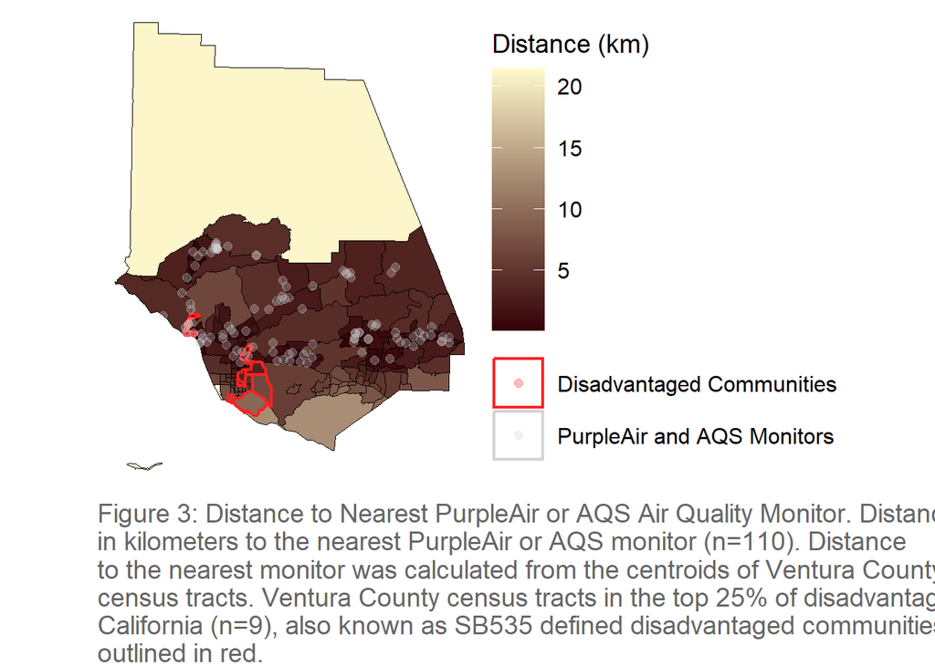

```r
#A glimpse at the matrix shows distances (in meters) between the first five Census tracts in the dataset and the first five AQS. When considering accessibility, we may be interested in the distance to the nearest AQS to each Census tract. The code below extracts the minimum distance from the matrix for each row, converts to a vector, and divides each value by 1000 to convert values to kilometers. A quick histogram visualizes the distribution of minimum distances.
min_dist_pa_aqs <- dist_pa_aqs %>%
  apply(1, min) %>%
  as.vector() %>%
  magrittr::divide_by(1000)

vc_tracts_pop$min_dist_pa_aqs <- min_dist_pa_aqs

ggplot() +
  geom_sf(data = vc_tracts_pop, aes(fill=min_dist_pa_aqs), color = "black") +
  scale_fill_gradient(low = "#330000", high =  "lemonchiffon") +
  geom_sf(data = CES4_tracts_sf, aes(color = "Disadvantaged Communities"), fill=NA, linewidth=0.8)+
  geom_sf(data = pa_aqs_sf_subset, aes(color = "PurpleAir and AQS Monitors"), alpha = .3, size=2) +
  #for geom_shadowtext have to make show.legend = FALSE or else I get a weird a over it
  #This was working before, and it works on my computer, but it doesn't work on the school computers anymore. Adding any sort of text like geom_text or geom_shadowtext makes my map very tiny now
  #geom_shadowtext(data=cities,
  #                aes(x=longitude, y=latitude, label=city), bg.color="gray75", bg.r=0.13, color="black",
  #                size=3, show.legend = FALSE)+
  theme_void() +
  labs(fill = "Distance (km)",
       caption = str_wrap("Figure 3: Distance to Nearest PurpleAir or AQS Air Quality Monitor. Distance in kilometers to the nearest PurpleAir or AQS monitor (n=110). Distance to the nearest monitor was calculated from the centroids of Ventura County census tracts. Ventura County census tracts in the top 25% of disadvantage for California (n=9), also known as SB535 defined disadvantaged communities, are outlined in red.")) +
  theme(plot.caption = element_text(hjust=0, size = 14, color = "#666666", family = "sans"),
        legend.text = element_text(size = 12, family = "sans"),
        legend.title = element_text(size = 14, family = "sans"),
        legend.key.size = unit(1, 'cm')) +
  labs(color = NULL) +
  scale_color_manual(values = c("PurpleAir and AQS Monitors" = "lightgrey", "Disadvantaged Communities" = "#fc2121"))
```

I only run what is below when I want to save this map as a .jpg.

```r
ggsave("figs/distance_monitor_disadvantage.jpg", width=8, height=7)
```

…And here is an interactive version of the above map. Feel free to zoom in, click on census tracts or any other points of interest.

```r
#I don't have as much experience with mapview, so I do not know how to change the scale gradient to the same one I used for the ggplot
#min_dist_pa_aqs is the minimum distance from the centroid of a census tract to the nearest PurpleAir or AQS station
mapview::mapview(vc_tracts_pop, zcol="min_dist_pa_aqs", layer.name="min_dist_pa_aqs")+
  mapview::mapview(CES4_tracts_sf, color="red", alpha.regions = 0, lwd=3, layer.name="Disadvantaged communities")+
  mapview::mapview(pa_aqs_sf_subset, color="grey", col.regions="lightgrey", layer.name="PurpleAir and AQS monitors")
```

[interactive chart not shown]

```r
#modelled after CES4_tracts_sf
stjoin_filter <- function(y,a,indicator){
 #called it y, a instead of x,y, because of below function... I know it might be confusing but im sorry im on time crunch
   st_join(y,a) %>%
    filter({{indicator}} >= 75)
}
```

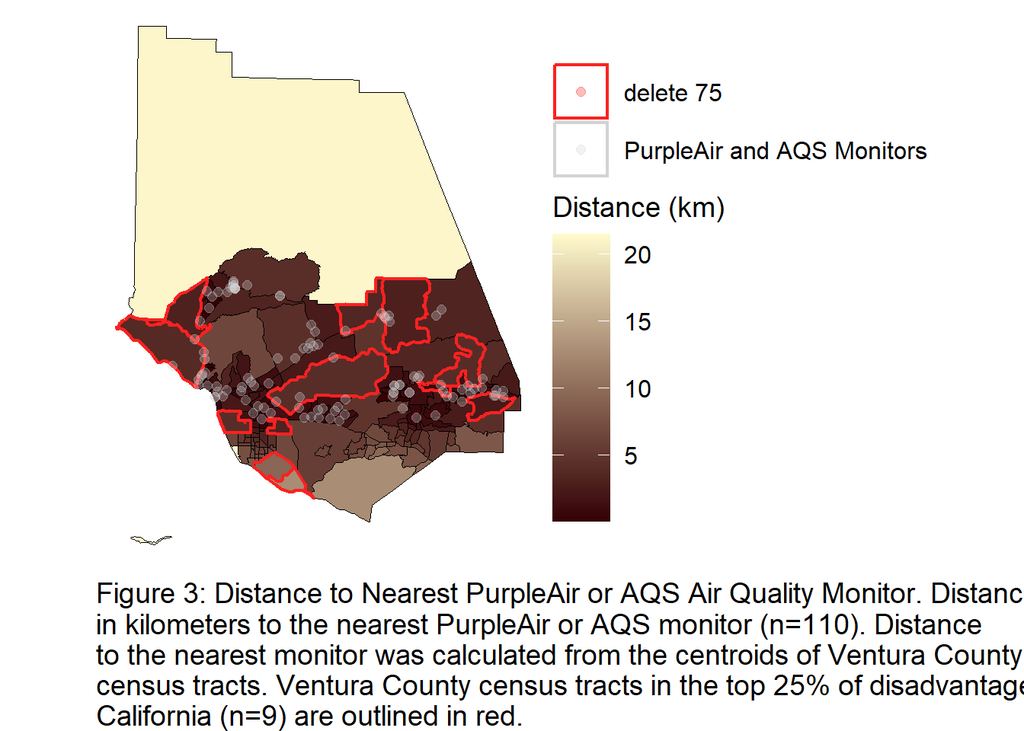

```r
CES4_delete_sf <- stjoin_filter(vc_tracts_pop, CES4_sf, `Solid Waste Pctl`)

ggplot() +
  geom_sf(data = vc_tracts_pop, aes(fill=min_dist_pa_aqs), color = "black") +
  scale_fill_gradient(low = "#330000", high =  "lemonchiffon") +
  geom_sf(data = CES4_delete_sf, aes(color = "delete 75"), fill=NA, linewidth=0.8)+
  geom_sf(data = pa_aqs_sf_subset, aes(color = "PurpleAir and AQS Monitors"), alpha = .3, size=2) +
  theme_void() +
  labs(fill = "Distance (km)",
       caption = str_wrap("Figure 3: Distance to Nearest PurpleAir or AQS Air Quality Monitor. Distance in kilometers to the nearest PurpleAir or AQS monitor (n=110). Distance to the nearest monitor was calculated from the centroids of Ventura County census tracts. Ventura County census tracts in the top 25% of disadvantage for California (n=9) are outlined in red.")) +
  theme(plot.caption = element_text(hjust=0, size = 14),
        plot.title = element_text(size = 20),
        legend.text = element_text(size = 12),
        legend.title = element_text(size = 14),
        legend.key.size = unit(1, 'cm')) +
  labs(color = NULL) +
  scale_color_manual(values = c("PurpleAir and AQS Monitors" = "lightgrey", "delete 75" = "#fc2121"))
```